# R Notebook

```r
library(tidyverse)
library(infer)
```

```r
data(msleep)
```

alpha = 0.05 H0: Sample animals sleep_total = jabberwockies Ha: Sample animals sleep_total != jabberwockies

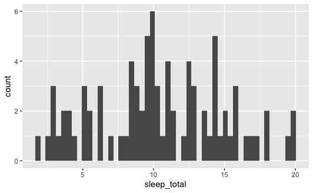

```r
msleep %>%
  ggplot(aes(x = sleep_total)) +
  geom_histogram(bins = 50)
```

```r
observed_stat <- msleep %>%
  summarise(mean_sleep = mean(sleep_total))

observed_stat
```

| mean_sleep |
| --- |
| 10.43373 |

```r
null_distribution <- msleep %>%
  specify(response = sleep_total) %>%
  hypothesise(null = "point", mu = 10.434) %>%
  generate(reps = 1000, type = "bootstrap") %>%
  calculate(stat = "mean")

null_distribution
```

| replicate | stat |
| --- | --- |
| 1 | 11.120747 |
| 2 | 11.894241 |
| 3 | 9.618337 |
| 4 | 11.135205 |
| 5 | 10.556892 |
| 6 | 10.176169 |
| 7 | 10.679783 |
| 8 | 10.078578 |
| 9 | 10.037614 |
| 10 | 10.740024 |

[output cut: 990 more lines]

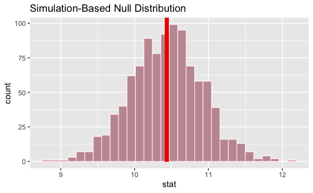

```r
null_distribution %>%
  visualise(bins = 30) +
  shade_p_value(obs_stat = observed_stat$mean_sleep, direction = "both")
```

```r
p_value <- null_distribution %>%
  get_p_value(obs_stat = observed_stat$mean_sleep, direction = "both")
p_value
```

| p_value |
| --- |
| 0.972 |

Perform an appropriate statistical test to determine whether omnivores sleep for significantly longer than herbivores, on average.

alpha = 0.05 H0: omnivores sleep_total = herbivores sleep_total Ha: omnivores sleep_total > herbivores sleep_total

[figure not shown]

```r
null_distribution <- vore_comparison %>%
  specify(response = sleep_total, explanatory = vore) %>%
  hypothesise(null = "independence") %>%
  generate(reps = 10000, type = "permute") %>%
  calculate(stat = "diff in means", order = c("omni", "herbi"))
null_distribution
```

| replicate | stat |
| --- | --- |
| 1 | -0.120000 |
| 2 | -1.501250 |
| 3 | -1.168125 |
| 4 | 1.399375 |
| 5 | -0.176875 |
| 6 | -1.671875 |
| 7 | -0.380000 |
| 8 | -0.339375 |
| 9 | 1.878750 |
| 10 | 0.838750 |

[output cut: 990 more lines]

```r
observed_stat <- vore_comparison %>%
  specify(response = sleep_total, explanatory = vore) %>%
  calculate(stat = "diff in means", order = c("omni", "herbi"))

observed_stat
```

| stat |
| --- |
| 1.415625 |

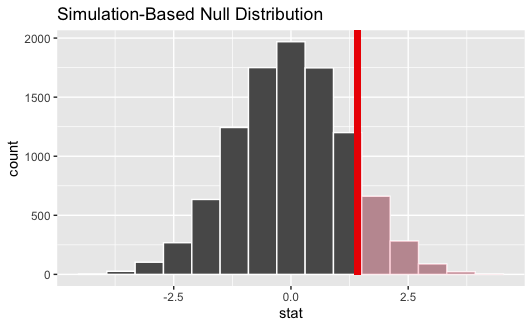

```r
null_distribution %>%
  visualise() +
  shade_p_value(obs_stat = observed_stat, direction = "right")
```

```r
null_distribution %>%
  get_p_value(obs_stat = observed_stat, direction = "right")
```

| p_value |
| --- |
| 0.1226 |

## p value > alpha, therefore fail to reject null hypothesis so cannot say for certain that omnivores sleep more than herbivores on average.

Perform an appropriate statistical test to determine whether the proportion of domesticated animal types in the population of animal types is greater than 5%. [Hint - think about creating an is_domesticated variable for the analysis]

```r
domesticates <- msleep %>%
  mutate(is_domesticated = ifelse(conservation == "domesticated", "domesticated", "not domesticated")) %>%
  mutate(is_domesticated = ifelse(is.na(conservation) == TRUE, "not domesticated", is_domesticated))
```

```r
prop_domesticated <- domesticates %>%
  group_by(is_domesticated) %>%
  summarise(prop = n() / nrow(domesticates)) %>%
  filter(is_domesticated == "domesticated")
```

alpha = 0.05 H0:prop_domesticated = 0.05 ha:prop_domesticated > 0.05

```r
null_distribution <- domesticates %>%
  specify(response = is_domesticated, success = "domesticated") %>%
  hypothesise(null = "point", p = 0.05) %>%
  generate(reps = 5000, type = "simulate") %>%
  calculate(stat = "prop")
```

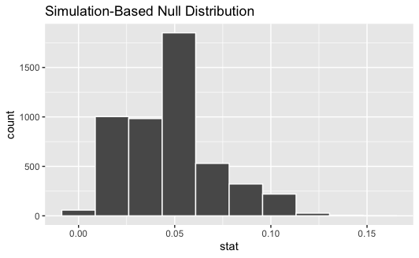

```r
null_distribution %>%
  visualise(bins = 10)
```

```r
observed_stat <- domesticates %>%
  specify(response = is_domesticated, success = "domesticated") %>%
  calculate(stat = "prop")

observed_stat
```

| stat |
| --- |
| 0.1204819 |

```r
null_distribution %>%
  get_p_value(obs_stat = observed_stat, direction = "right")
```

| p_value |
| --- |
| 0.0068 |

p value < alpha, therefore reject H0 and it can be said that the proportion of domesticated animals > 0.05.

# Hypothesis Testing - Interpretation

1. H0: pi_before_marketing = pi_after_marketing Ha: pi_after_marketing > pi_before_marketing

   H0: % Customer awareness of coffee store after marketing campaign = 40% Ha: % Customer awareness of coffee store after marketing campaign > 40%

   Method = permutation
2. H0: pi_CTR_group1 = pi_CTR_test_group Ha: pi_CTR_test_group > pi_CTR_group1

   Method = permutation
3. H0: mu_mean_width = 145mm Ha: mu_mean_width != 145mm

   H0: the mean width of the sample parts is equal to 145 mm Ha: the mean width of the sample parts is not equal to 145 mm

   Method = bootstrap

# Interpreting the Results

1. p value greater than alpha, therefore fail to reject null hypothesis therefore it can be said that there is no statistically significant increase in the % awareness of the coffee shop after marketing campaign.
2. p value less than alpha, reject null hypothesis. It can be said that the test group had a statistically significantly higher click through rate than group 1, therefore banner position made a statistically significant increase to click through rate.
3. p value greater than alpha, therefore fail to reject null hypothesis. It can be said that it is statistically likely that the mean width of population parts is 145mm.